# Markdown tutorial

Dr.Sc. Oleksii Yehorchenkov

Department of Spatial Planning

## About Markdown

For more details on using Markdown see https://www.markdownguide.org/basic-syntax/.

## About Markdown

When you click the button (or in case of quarto documents) a document will be generated that includes both content as well as the output of any embedded R code chunks within the document. You can embed an R code chunk like this:

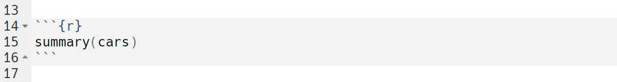

```
     speed           dist
 Min.   : 4.0   Min.   :  2.00
 1st Qu.:12.0   1st Qu.: 26.00
 Median :15.0   Median : 36.00
 Mean   :15.4   Mean   : 42.98
 3rd Qu.:19.0   3rd Qu.: 56.00
 Max.   :25.0   Max.   :120.00
```

## Markdown syntaxis

### Headings

To create a heading, add number signs (#) in front of a word or phrase. The number of number signs you use should correspond to the heading level.

```markdown
# Heading level 1

## Heading level 2

### Heading level 3
```

# Heading level 1

## Heading level 2

### Heading level 3

### Paragraphs

To create paragraphs, use a blank line to separate one or more lines of text.

```markdown
I really like using Markdown.

I think I'll use it to format all of my documents from now on.
```

I really like using Markdown.

I think I’ll use it to format all of my documents from now on.

### Emphasis

You can add emphasis by making text bold or italic.

To bold text, add two asterisks or underscores before and after a word or phrase. To bold the middle of a word for emphasis, add two asterisks without spaces around the letters.

```markdown
I just love **bold text**.
```

I just love **bold text**.

To italicize text, add one asterisk or underscore before and after a word or phrase. To italicize the middle of a word for emphasis, add one asterisk without spaces around the letters.

```markdown
Italicized text is the *cat's meow*.
```

Italicized text is the *cat’s meow*.

### Lists

You can organize items into ordered and unordered lists.

To create an ordered list, add line items with numbers followed by periods. The numbers don’t have to be in numerical order, but the list should start with the number one.

```markdown
1.  First item
2.  Second item
3.  Third item
4.  Fourth item
```

1. First item
2. Second item
3. Third item
4. Fourth item

### Unordered lists

To create an unordered list, add dashes (-), asterisks (*), or plus signs (+) in front of line items. Indent one or more items to create a nested list.

```markdown
-   First item
-   Second item
-   Third item
-   Fourth item
```

- First item
- Second item
- Third item
- Fourth item